# U2. Aplicación

Sebastian Freille

Universidad Nacional de Córdoba

# Preferencias electorales (Twitter)

[figure not shown]

Figura 1: Eligiendo de a pares

# Combinando de a pares

- Sean entonces las siguientes alternativas
  1. Bullrich (BU)
  2. Larreta (LA)
  3. Massa (MA)
  4. Milei (MI)
- En principio esto nos da 6 (seis) combinaciones posibles
  - 1. Bullrich-Larreta, (2) Bullrich-Massa, (3) Bullrich-Milei, (4) Larreta-Massa, (5) Larreta-Milei y (6) Massa-Milei
    - Note que (1) no es factible de suceder

# Ordenamientos posibles

| **Bullrich** | **Larreta** | **Massa** | **Milei** |
| --- | --- | --- | --- |
| BU > LA > MA > MI | LA > BU > MA > MI | MA > BU > LA > MI | MI > BU > LA > MA |
| BU > LA > MI > MA | LA > BU > MI > MA | MA > BU > MI > LA | MI > BU > MA > LA |
| BU > MA > LA > MI | LA > MA > BU > MI | MA > LA > BU > MI | MI > LA > BU > MA |
| BU > MA > MI > LA | LA > MA > MI > BU | MA > LA > MI > BU | MI > LA > MA > BU |
| BU > MI > LA > MA | LA > MI > BU > MA | MA > MI > BU > LA | MI > MA > BU > LA |
| BU > MI > MA > LA | LA > MI > MA > BU | MA > MI > LA > BU | MI > MA > LA > BU |

# Posicionamiento de cada candidato

- Supongamos que los candidatos pueden ser ordenados en una sola dimensión de política –regulación/desregulación económica- y por simplicidad supongamos que pueden ordenarse así en una recta donde más a la izquierda significa mayor regulación y más a la derecha significa más desregulación
- MA —————- LA —————- BU —————–MI

# ¿Hay preferencias “raras”?

- Piense en la preferencia $MI > MA > LA > BU$ o $MA > MI > LA > BU$
  - ¿qué tiene de “raro” o extrañas esas preferencias?
- Estas preferencias tienden a ordenar valores más alejados de las preferncias mas fuertes “más arriba” que valores más cercanos de las preferencias más fuertes (puntos ideales)
- ¿Es esto un problema para agregar opiniones y decisiones individuales? Teóricamente si. Practicamente depende del contexto y situación

# Preferencias de pico único

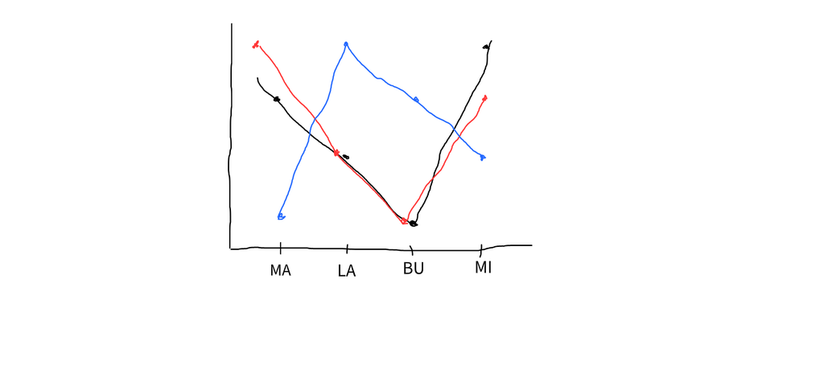

Figura 2: Preferencias de pico único

# IAA

- Este criterio dice básicamente que si $LA > BU > MI$ que aparezca una nueva opción $MA$ no debería cambiar el ordenamiento de ese grupo entre $LA$, $BU$ y $MI$. En efecto, tanto:
  - $LA > BU > MI > MA$
  - $MA > LA > BU > MI$
- serían viables y no violarían el criterio de independencia de alternativas irrelevantes
  - ejemplo $\longrightarrow$ tomamos un avión y a la hora de la cena nos preguntan “Carne o pasta”. Elegimos carne. Justo en ese momento, informan que además hay ensalada. Ante esa información, elegimos pasta.

# ¿Cambiamos nuestra preferencia ante presencia/ausencia de alternativas?

[figure not shown]

Figura 3